# Telco Customer Churn Analysis

Who leaves, why, and how to keep them

Author

Nanxi Chen

Published

October 7, 2026

## 1. Business Question

About a quarter of the customers in this telecom dataset (26.6%) left the company in the last month. This analysis asks three questions:

1. Which customers are most likely to churn?
2. What factors are associated with churn?
3. How can the company target its retention budget?

## 2. Data

The data is the public IBM Telco Customer Churn sample: about 7,000 customers with their account details, services and whether they left in the last month.

```r
library(tidyverse)
library(broom)
library(ranger)
set.seed(2026)

data_url  <- "https://raw.githubusercontent.com/IBM/telco-customer-churn-on-icp4d/master/data/Telco-Customer-Churn.csv"
data_path <- "data/Telco-Customer-Churn.csv"

if (!file.exists(data_path)) {
  dir.create("data", showWarnings = FALSE)
  download.file(data_url, data_path)
}

raw <- read_csv(data_path)
glimpse(raw)
```

```
Rows: 7,043
Columns: 21
$ customerID       <chr> "7590-VHVEG", "5575-GNVDE", "3668-QPYBK", "7795-CFOCW~
$ gender           <chr> "Female", "Male", "Male", "Male", "Female", "Female",~
$ SeniorCitizen    <dbl> 0, 0, 0, 0, 0, 0, 0, 0, 0, 0, 0, 0, 0, 0, 0, 0, 0, 0,~
$ Partner          <chr> "Yes", "No", "No", "No", "No", "No", "No", "No", "Yes~
$ Dependents       <chr> "No", "No", "No", "No", "No", "No", "Yes", "No", "No"~
$ tenure           <dbl> 1, 34, 2, 45, 2, 8, 22, 10, 28, 62, 13, 16, 58, 49, 2~
$ PhoneService     <chr> "No", "Yes", "Yes", "No", "Yes", "Yes", "Yes", "No", ~
$ MultipleLines    <chr> "No phone service", "No", "No", "No phone service", "~
$ InternetService  <chr> "DSL", "DSL", "DSL", "DSL", "Fiber optic", "Fiber opt~
$ OnlineSecurity   <chr> "No", "Yes", "Yes", "Yes", "No", "No", "No", "Yes", "~
$ OnlineBackup     <chr> "Yes", "No", "Yes", "No", "No", "No", "Yes", "No", "N~
$ DeviceProtection <chr> "No", "Yes", "No", "Yes", "No", "Yes", "No", "No", "Y~
$ TechSupport      <chr> "No", "No", "No", "Yes", "No", "No", "No", "No", "Yes~
$ StreamingTV      <chr> "No", "No", "No", "No", "No", "Yes", "Yes", "No", "Ye~
$ StreamingMovies  <chr> "No", "No", "No", "No", "No", "Yes", "No", "No", "Yes~
$ Contract         <chr> "Month-to-month", "One year", "Month-to-month", "One ~
$ PaperlessBilling <chr> "Yes", "No", "Yes", "No", "Yes", "Yes", "Yes", "No", ~
$ PaymentMethod    <chr> "Electronic check", "Mailed check", "Mailed check", "~
$ MonthlyCharges   <dbl> 29.85, 56.95, 53.85, 42.30, 70.70, 99.65, 89.10, 29.7~
$ TotalCharges     <dbl> 29.85, 1889.50, 108.15, 1840.75, 151.65, 820.50, 1949~
$ Churn            <chr> "No", "No", "Yes", "No", "Yes", "Yes", "No", "No", "Y~
```

### Cleaning

`TotalCharges` is missing for 11 brand-new customers (tenure of zero months), so they are removed. Text columns are converted to categories.

```r
churn <- raw |>
  select(-customerID) |>
  mutate(
    TotalCharges  = as.numeric(TotalCharges),
    SeniorCitizen = if_else(SeniorCitizen == 1, "Yes", "No"),
    across(where(is.character), as.factor),
    Churn = factor(Churn, levels = c("No", "Yes"))
  ) |>
  drop_na()

nrow(churn)
```

```
[1] 7032
```

```r
churn |>
  count(Churn) |>
  mutate(share = scales::percent(n / sum(n), accuracy = 0.1))
```

```
# A tibble: 2 x 3
  Churn     n share
  <fct> <int> <chr>
1 No     5163 73.4%
2 Yes    1869 26.6%
```

## 3. Who Churns?

```r
churn_rate_by <- function(data, var) {
  data |>
    group_by({{ var }}) |>
    summarise(
      customers  = n(),
      churn_rate = mean(Churn == "Yes"),
      .groups = "drop"
    )
}
```

### Contract type

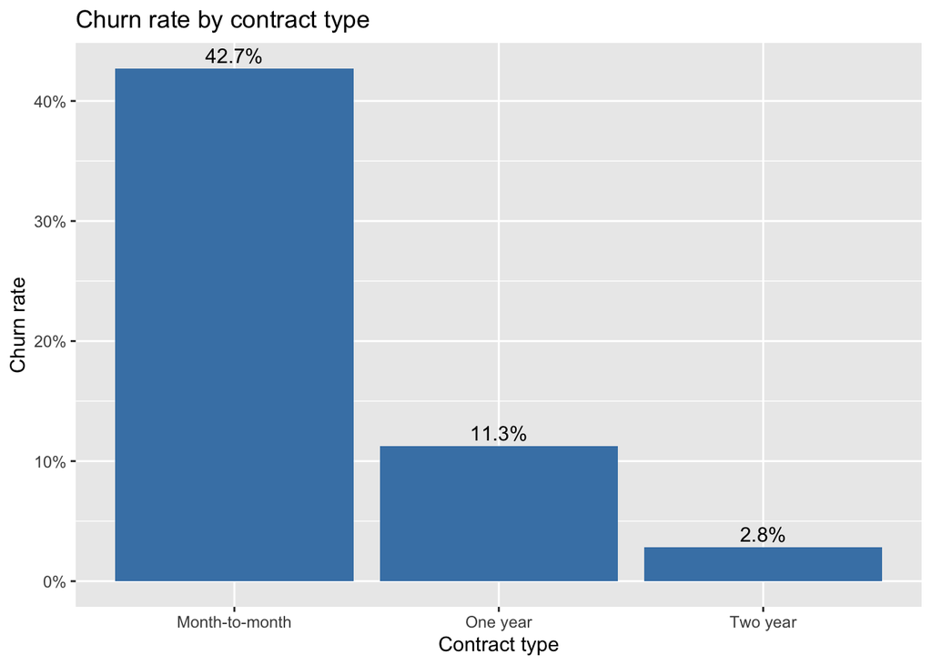

```r
churn_rate_by(churn, Contract) |>
  ggplot(aes(x = reorder(Contract, -churn_rate), y = churn_rate)) +
  geom_col(fill = "steelblue") +
  geom_text(aes(label = scales::percent(churn_rate, accuracy = 0.1)), vjust = -0.4) +
  scale_y_continuous(labels = scales::percent) +
  labs(x = "Contract type", y = "Churn rate", title = "Churn rate by contract type")
```

### Tenure

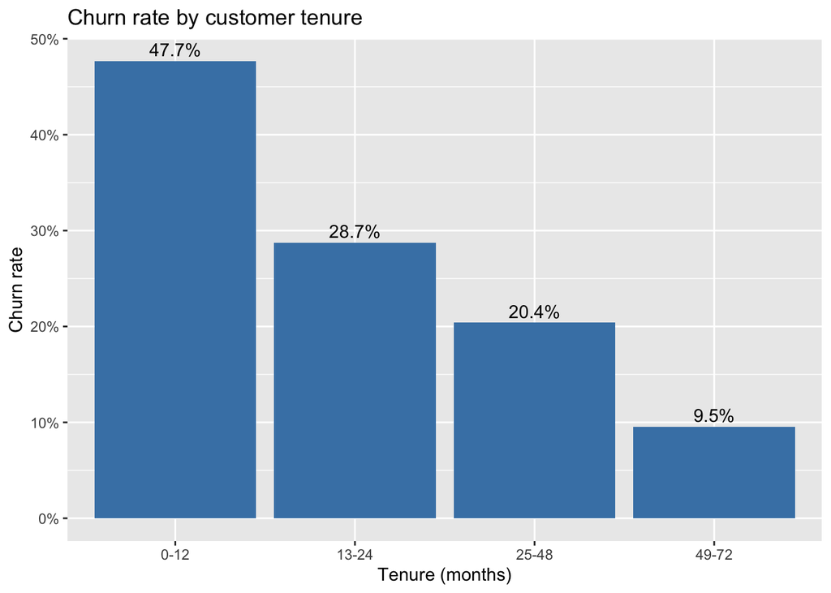

```r
churn |>
  mutate(tenure_group = cut(
    tenure,
    breaks = c(0, 12, 24, 48, 72),
    labels = c("0-12", "13-24", "25-48", "49-72"),
    include.lowest = TRUE
  )) |>
  churn_rate_by(tenure_group) |>
  ggplot(aes(x = tenure_group, y = churn_rate)) +
  geom_col(fill = "steelblue") +
  geom_text(aes(label = scales::percent(churn_rate, accuracy = 0.1)), vjust = -0.4) +
  scale_y_continuous(labels = scales::percent) +
  labs(x = "Tenure (months)", y = "Churn rate", title = "Churn rate by customer tenure")
```

### Monthly charges

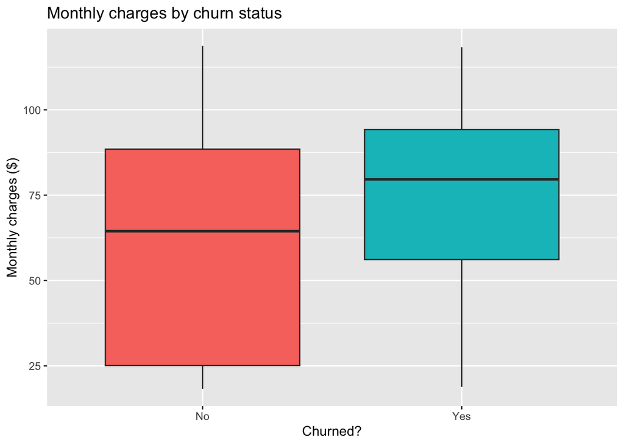

```r
ggplot(churn, aes(x = Churn, y = MonthlyCharges, fill = Churn)) +
  geom_boxplot(show.legend = FALSE) +
  labs(x = "Churned?", y = "Monthly charges ($)", title = "Monthly charges by churn status")
```

### Payment method and internet service

```r
churn_rate_by(churn, PaymentMethod) |> arrange(desc(churn_rate))
```

```
# A tibble: 4 x 3
  PaymentMethod             customers churn_rate
  <fct>                         <int>      <dbl>
1 Electronic check               2365      0.453
2 Mailed check                   1604      0.192
3 Bank transfer (automatic)      1542      0.167
4 Credit card (automatic)        1521      0.153
```

```r
churn_rate_by(churn, InternetService) |> arrange(desc(churn_rate))
```

```
# A tibble: 3 x 3
  InternetService customers churn_rate
  <fct>               <int>      <dbl>
1 Fiber optic          3096     0.419
2 DSL                  2416     0.190
3 No                   1520     0.0743
```

## 4. Train/Test Split

The models are built on 70% of customers and evaluated on the remaining 30%, which they have never seen.

```r
idx   <- sample(nrow(churn), size = round(0.7 * nrow(churn)))
train <- churn[idx, ]
test  <- churn[-idx, ]
```

## 5. Logistic Regression: What Is Associated with Churn?

An odds ratio above 1 means higher odds of churning; below 1 means lower odds, holding the other variables constant.

```r
logit <- glm(
  Churn ~ tenure + MonthlyCharges + Contract + InternetService +
    PaymentMethod + PaperlessBilling + SeniorCitizen,
  data = train,
  family = binomial
)

tidy(logit, exponentiate = TRUE, conf.int = TRUE) |>
  mutate(across(where(is.numeric), \(x) round(x, 3)))
```

```
# A tibble: 12 x 7
   term                  estimate std.error statistic p.value conf.low conf.high
   <chr>                    <dbl>     <dbl>     <dbl>   <dbl>    <dbl>     <dbl>
 1 (Intercept)              0.443     0.212    -3.84    0        0.292     0.67
 2 tenure                   0.97      0.003   -12.3     0        0.965     0.975
 3 MonthlyCharges           1.00      0.004     1.04    0.299    0.997     1.01
 4 ContractOne year         0.441     0.122    -6.68    0        0.346     0.559
 5 ContractTwo year         0.194     0.208    -7.90    0        0.127     0.287
 6 InternetServiceFiber~    2.30      0.152     5.50    0        1.71      3.10
 7 InternetServiceNo        0.517     0.18     -3.66    0        0.362     0.735
 8 PaymentMethodCredit ~    0.909     0.133    -0.715   0.475    0.701     1.18
 9 PaymentMethodElectro~    1.52      0.108     3.85    0        1.23      1.88
10 PaymentMethodMailed ~    0.964     0.132    -0.277   0.782    0.744     1.25
11 PaperlessBillingYes      1.34      0.086     3.40    0.001    1.13      1.59
12 SeniorCitizenYes         1.32      0.097     2.84    0.005    1.09      1.59
```

## 6. Random Forest: Who Will Churn Next?

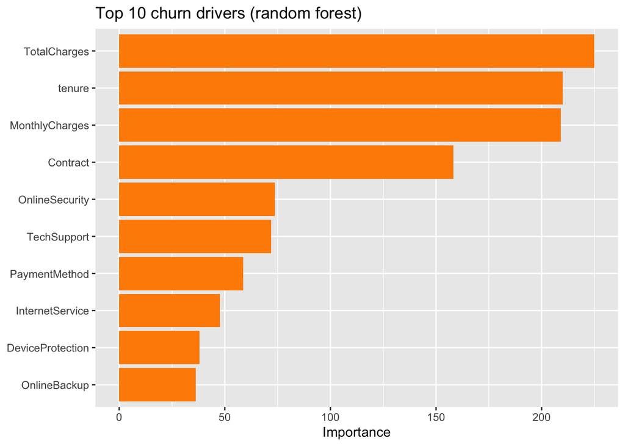

```r
rf <- ranger(
  Churn ~ .,
  data = train,
  probability = TRUE,
  num.trees = 500,
  importance = "impurity"
)

tibble(
  variable   = names(rf$variable.importance),
  importance = rf$variable.importance
) |>
  slice_max(importance, n = 10) |>
  ggplot(aes(x = reorder(variable, importance), y = importance)) +
  geom_col(fill = "darkorange") +
  coord_flip() +
  labs(x = NULL, y = "Importance", title = "Top 10 churn drivers (random forest)")
```

## 7. Model Comparison

Recall is the share of real churners the model catches; precision is the share of flagged customers who really churn. For a retention campaign, missing a churner is usually more costly than contacting a loyal customer, so a lower threshold (0.3) is also tested.

```r
evaluate <- function(prob, truth, threshold) {
  pred <- if_else(prob >= threshold, "Yes", "No")
  tibble(
    threshold = threshold,
    accuracy  = mean(pred == truth),
    recall    = sum(pred == "Yes" & truth == "Yes") / sum(truth == "Yes"),
    precision = sum(pred == "Yes" & truth == "Yes") / sum(pred == "Yes")
  )
}

p_logit <- predict(logit, newdata = test, type = "response")
p_rf    <- predict(rf, data = test)$predictions[, "Yes"]

bind_rows(
  evaluate(p_logit, test$Churn, 0.5) |> mutate(model = "Logistic regression"),
  evaluate(p_logit, test$Churn, 0.3) |> mutate(model = "Logistic regression"),
  evaluate(p_rf,    test$Churn, 0.5) |> mutate(model = "Random forest"),
  evaluate(p_rf,    test$Churn, 0.3) |> mutate(model = "Random forest")
) |>
  relocate(model) |>
  mutate(across(where(is.numeric), \(x) round(x, 3)))
```

```
# A tibble: 4 x 5
  model               threshold accuracy recall precision
  <chr>                   <dbl>    <dbl>  <dbl>     <dbl>
1 Logistic regression       0.5    0.808  0.54      0.643
2 Logistic regression       0.3    0.758  0.797     0.513
3 Random forest             0.5    0.801  0.488     0.64
4 Random forest             0.3    0.764  0.78      0.523
```

## 8. Key Findings

1. **Contract type:** Month-to-month customers churn at 42.7%, compared with 2.8% for two-year contracts.
2. **Tenure:** Customers in their first year churn at 47.7%, the highest of any tenure group.
3. **Charges:** Churners pay higher monthly charges (median $79.6 vs $64.4).
4. **Model:** Lowering the threshold from 0.5 to 0.3 raises the random forest’s recall from 0.49 to 0.78, at the cost of precision falling from 0.64 to 0.52.

## 9. Recommendations

1. **Convert month-to-month customers:** offer a discount for switching to an annual contract, targeted at customers in their first 12 months.
2. **Focus on early tenure:** strengthen onboarding during the first year, when churn is highest.
3. **Target with the model:** use the random forest with a 0.3 threshold to build a monthly retention list, accepting more false alarms in exchange for catching more churners.
4. **Review the electronic check experience:** customers paying by electronic check churn at 45.3%, far above those on automatic payments (about 15–17%); encouraging a switch to automatic payment could reduce churn.

## 10. Limitations

- The data is a public sample, and the results show associations, not causes.
- The threshold of 0.3 is illustrative; in practice it should be set using the actual cost of a retention offer and the value of a retained customer.